# When Do AI-Written Clinician Comments Fall Short of Real Ones? Topic, Model, Prompting Strategy, Severity and Cancer as Moderators

# 1 In short

Earlier analyses showed that AI-written replies to patient questions show less empathy than real clinician replies. This report asks **when** the gap is larger or smaller. We tested five things that might change it: the medical topic of the question, *which* AI model wrote the reply, which *prompting strategy* the model was given, how severe the patient’s problem is, and whether cancer is involved.

- **The gap depends strongly on the kind of empathy.** On average, AI replies are much less likely than real ones to react emotionally (odds ratio 0.087) or to explore the patient’s experience (0.055). For interpretations the average is closer to parity (0.87).
- **The three AI models differ a lot, and for interpretations they differ in direction.** Grok’s replies show interpretation *more* often than real clinicians’ (odds ratio 1.95); Gemini’s (0.44) and OpenAI’s (0.74) show it less often. Averaging over models hides this.
- **Topic matters, but modestly and mostly for explorations.** The gap varies across the 11 topics for all three kinds of empathy (9 topic-level differences are credible), but the pattern is topic-specific rather than one topic standing out everywhere. Dermatology is the clearest case: AI explores relatively *more* there, and reacts emotionally relatively *less*.
- **Topic effects are mostly shared across models and prompting strategies.** Only 2 of the model-versus-model comparisons within a topic are credible, both for explorations. Allowing the topic effect to differ by model or by strategy adds almost nothing, except for explorations, where it differs by model (Section 4.6).
- **Severity matters for interpretations.** The more severe the problem, the more AI replies catch up with real ones on interpretations, for all three models and under every prompting strategy. For emotional reactions this holds for Gemini and OpenAI only; for explorations we find no effect.
- **Cancer-related questions shift the gap in opposite directions for interpretations (AI relatively better) and explorations (AI relatively worse).**
- **Prompting strategy matters much less than the model, but not nothing.** Averaged over the three models, the strategies differ clearly only for emotional reactions (DG falls furthest behind real replies; ratios to SAG and SAGII 0.69 (0.59-0.80) and 0.81 (0.69-0.96)); for interpretations there is only a borderline difference, and for explorations none. Within single models, 10 of 27 strategy comparisons are credible, and the pattern is model-specific (for example, OpenAI’s DG replies trail real ones most in emotional reactions), so there is no single “best” strategy (Section 4.6).
- **Reply length changes the interpretation story.** Longer replies are far more likely to be classified as showing interpretation (the odds roughly 2.50 times for each doubling of length). OpenAI’s replies are more than twice as long as real ones (median 80 vs. 34 words). Without length adjustment OpenAI therefore appears to show *more* interpretation than real clinicians (gap 1.33 (1.21-1.45)); at equal length it shows less (0.74 (0.67-0.82)). Both versions are reported side by side (Section 4.6.1).
- **The results do not depend on how we handle the surplus of AI replies.** Randomly thinning AI replies, instead of weighting them, changes estimated odds ratios by at most 14% and does not change the pattern of findings; only borderline comparisons change their credibility status (Section 4.8).

Everything here describes what automatic classifiers detect in text, and the topic labels are themselves machine-made and imperfect (see Section 3).

# 2 The study in plain terms

## 2.1 The data

Each item is a patient question posted on Reddit’s r/AskDocs. For each of the 6,600 threads we have the replies of real, verified clinicians (8,625 replies) and replies written by three AI models (Gemini, OpenAI, Grok) given the same post, each under three prompting strategies (128,653 AI replies in total). We keep the nine model-by-strategy combinations apart in the models. The main results are reported per AI model; Section 4.6 examines the prompting strategies themselves.

## 2.2 What was measured

Three classifiers, trained on the EPITOME framework of empathy in text-based support, rated every reply on three kinds of empathy:

- **Emotional reaction (ER):** expressing warmth, concern or sympathy (“I’m sorry you’re dealing with this”).
- **Interpretation (IP):** showing an understanding of what the patient is feeling or experiencing (“it sounds like this has been worrying you”).
- **Exploration (EX):** probing the patient’s experience with follow-up questions (“how long has this been going on?”).

Each is rated none, weak or strong. Replies with any empathy are uncommon, so we ask a yes/no question: *does this reply show this kind of empathy at all?* Table 2.1 gives the raw rates, adjusted so that a thread’s AI replies carry no more total weight than its real replies (see “Making a fair comparison”).

Table 2.1: Share of replies showing each kind of empathy (weighted).

|  | Emotional reaction | Interpretation | Exploration |
| --- | --- | --- | --- |
| AI: Gemini | 6.7% | 3.6% | 5.2% |
| AI: Grok | 0.8% | 11.2% | 1.8% |
| AI: OpenAI | 3.1% | 12.5% | 0.9% |
| Real clinicians | 14.7% | 10.7% | 18.9% |

## 2.3 The four moderators

A *moderator* is a variable that changes the size of an effect; here, the real-vs-AI gap. We examined these four in the main analysis; the prompting strategy, a fifth factor, is examined in Section 4.6.

1. **Topic.** A language model read each opening post and assigned one of 17 medical disciplines (taxonomy from Chan et al., 2025). The label belongs to the thread, so a reply to a skin question is a “dermatology” reply whether a clinician or an AI wrote it. We merged some related disciplines (cardiology with pulmonology, dentistry with otolaryngology, neurology with ophthalmology, haematology/immunology with infectious diseases) and left out the two catch-all labels (“Medical; other”, “Nonmedical”), leaving 11 topics and 6,200 threads (Table 2.2). 1 topic (Neoplasms) is small (under 5% of threads); it stays in the analysis but is flagged as exploratory.
2. **Which AI model** wrote the reply: does a topic affect Gemini, OpenAI and Grok differently?
3. **Cancer relevance.** A language-model flag for threads where cancer is involved (518 threads; 2 threads without a flag are dropped from this analysis only).
4. **Severity.** A 1-4 triage score for how serious the patient’s problem is, from a collaborator’s rating of each post. 484 threads have no usable score (almost all rated “not applicable”); we do not treat these as low severity but give them their own indicator.

Table 2.2: The topics used in the analysis.

| Topic | Threads | Share of all threads | Exploratory (< 5%) |
| --- | --- | --- | --- |
| Hematologic, immunologic, and infectious conditions | 898 | 13.6% |  |
| Dermatology | 715 | 10.8% |  |
| Gastroenterology | 711 | 10.8% |  |
| Genitourinary and reproductive health | 695 | 10.5% |  |
| Cardiopulmonary conditions | 672 | 10.2% |  |
| Psychiatry and mental health | 596 | 9.0% |  |
| Neurologic and visual conditions | 594 | 9.0% |  |
| Endocrinology, nutrition, and metabolism | 439 | 6.7% |  |
| Musculoskeletal and connective tissue conditions | 362 | 5.5% |  |
| Oral and otolaryngologic conditions | 345 | 5.2% |  |
| Neoplasms | 173 | 2.6% | yes |

## 2.4 Other variables we controlled for

A collaborator proposed several thread-level variables. All models adjust for them: who the post is about (the poster or someone else), the patient’s age and sex where stated, severity, and whether the first responder’s declared specialty matches the topic of the post (real replies only, since the AI has no specialty). Missing values are coded with their own indicator rather than guessed. Because these variables belong to the thread, and each thread already has its own baseline in the models, they can only change the real-vs-AI gap if we ask them to; severity is the one we tested that way. For the others we report the effects on how often replies show empathy at all (Section 4.7).

## 2.5 Making a fair comparison

- **Replies in a thread are not independent.** A frightening question may draw empathy from everyone. Each thread has its own baseline in the model (a random intercept), so the comparison of real and AI replies is made *within* threads.
- **AI models wrote more replies than there were real ones.** If a thread has 2 real replies and a model wrote 8, each of its 8 replies counts for 1/4, so both sides carry equal weight. This uses all the data and avoids the arbitrariness of randomly discarding replies. Reported intervals are approximate under this scheme.

## 2.6 How to read the numbers

- **Odds ratio (OR).** The odds of a reply showing empathy are P/(1-P). The *gap* is the AI-to-real ratio of these odds *within the same thread*: below 1 means AI is less likely to show empathy, 0.5 means half the odds, above 1 means more likely. Because the comparison is within threads, these ratios are more extreme than the raw percentages in Table 2.1 would suggest.
- **Shift.** How much a moderator multiplies the gap relative to its average. For a topic: shift 1.3 means the gap is 1.3 times the average gap in that topic. If the average gap is below 1, a shift above 1 therefore means the AI is *closer to* real replies than average there.
- **95% credible interval.** The range that holds the true value with 95% probability given the data and model (a Bayesian analogue of a confidence interval).
- **pd (probability of direction).** The posterior probability that the effect has the sign we report. It is not a p-value. We call a result **credible** when pd exceeds 0.975 *and* the interval excludes 1.
- **Partial pooling.** Topic effects are treated like random effects: topics with plenty of threads get mostly their own estimate, topics with few are pulled toward the average. This guards against over-reading small topics and is why we apply no separate multiple-comparison correction.

# 3 What to keep in mind

- **Topic labels are noisy.** The labelling model agrees with a 200-post reference set about 77% of the time, and the reference was itself built largely by language models. Roughly one label in four may be off. Noise in a grouping variable blurs real differences, so a missing topic effect is weaker evidence than it looks, and detected ones are probably underestimates.
- **Topic comes from the post, not the reply.** A reply that wanders off topic keeps the post’s label.
- **Many comparisons, partial protection.** We look at 33 pooled topic shifts and 99 model-specific ones. Pooling limits false alarms, but around one in forty estimates can look credible by chance. Treat individual topics as leads, not conclusions, especially the exploratory topic.
- **Strategies and topic.** The per-model topic shifts in Section 4.3 are shared by a model’s three prompting strategies. Whether topic effects differ by strategy is examined only through variance components (Section 4.6), not topic by topic.
- **Reply length.** Length strongly affects what the classifiers detect and is partly a consequence of the strategy. Gaps are shown with and without adjusting for it; neither is the single “correct” answer (Section 4.6.1).
- **Classifiers, not people.** All results describe what the classifiers detect.
- **Severity and specialty match are observational covariates.** Severity is a rating of the post; specialty match is partly a choice by whoever answers. We report associations, not causes.
- **Subsampling check is a single draw.** Randomly thinning AI replies instead of weighting them gives the same picture (Section 4.8), but we ran one random thinning, so draw-to-draw variation is not quantified.

# 4 Results

## 4.1 Model checks

11 of 12 fits met every convergence criterion. The exception: Interpretations, pooled topic model (effective-sample-size ratio 0.085, 2 divergent transitions). Fits that initially fell short were rerun with twice as many iterations (Methods); this did not change which effects are credible.

11 of 13 prompting-strategy fits met every convergence criterion. The exceptions: Interpretations, severity-by-group model (2 divergent transitions); Explorations, topic-by-model-and-strategy model (3 divergent transitions). The largest Rhat among them is 1.0096 and the smallest effective-sample-size ratio 0.103; four fits that were marginal at 2,000 iterations were refitted with 4,000. The few divergent transitions that remain are a handful out of 12,000 draws per fit, and Rhat and effective sample size are fine for these fits; we report them with that caveat. The key results for the affected fits (severity for interpretations, topic variation for explorations) are reproduced in the independent subsampling check below. 6 of 12 subsampling-check fits met every convergence criterion. The exceptions: Emotional Reactions, strategy model without length adjustment (max Rhat 1.0104); Interpretations, strategy model without length adjustment (max Rhat 1.0101); Interpretations, strategy model with length adjustment (max Rhat 1.0105); Interpretations, topic-by-model-and-strategy model (1 divergent transition); Explorations, severity-by-group model (1 divergent transition); Explorations, topic-by-model-and-strategy model (1 divergent transition). The shortfalls in the subsampling check are marginal as well (max Rhat 1.0105).

## 4.2 The average gap, and how much it varies by topic

Table 4.1 shows the average gap and how much it moves from topic to topic. “Spread” is the standard deviation of the topic shifts on the log-odds scale; a spread of 0.44 means a typical topic multiplies the gap by about $e^{0.44} \approx 1.55$ (or divides it by that).

Table 4.1: Average real-vs-AI gap (all AI replies pooled) and its variation across topics.

| Empathy type | Average gap, OR (95% CrI) | Spread across topics, SD (95% CrI) | Typical factor |
| --- | --- | --- | --- |
| Emotional Reactions | 0.087 (0.073-0.11) | 0.21 (0.08-0.41) | x1.23 |
| Interpretations | 0.87 (0.71-1.05) | 0.25 (0.12-0.43) | x1.29 |
| Explorations | 0.055 (0.041-0.078) | 0.43 (0.23-0.75) | x1.54 |

The spread’s lower bound is clearly above zero (above 0.05) for 3 of 3 kinds of empathy, so topic does change the gap. The effect is largest for explorations. Figure 4.1 shows each topic’s gap; filled points are topics whose shift from the average is credible.

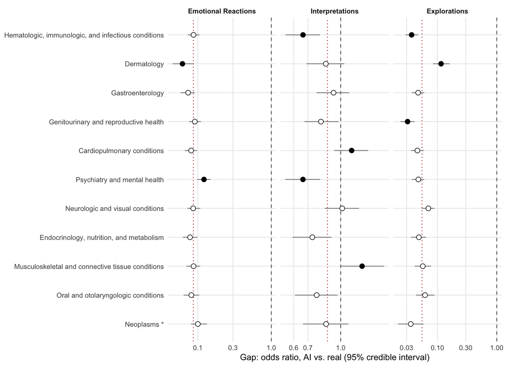

Figure 4.1: Real-vs-AI gap by topic (odds ratio, log scale; below 1 = AI less likely to show empathy). Filled points: credible shift from the average. Starred: under 5% of threads (exploratory). Dashed line: no gap; dotted red line: average over topics.

9 of the 33 topic shifts are credible (Table 4.2). For Emotional Reactions and Explorations the AI trails real replies in every topic and the topic only changes by how much. For Interpretations the AI is on par with or ahead of real replies in some topics (cardiopulmonary, neurologic and visual, and musculoskeletal); in none of them does the interval lie clearly above 1, with musculoskeletal the closest.

Table 4.2: Topics whose gap credibly differs from the average (pooled AI replies).

| Empathy type | Topic | Threads | Gap, OR (95% CrI) | Shift, OR (95% CrI) | pd | Reading |
| --- | --- | --- | --- | --- | --- | --- |
| Emotional Reactions | Dermatology | 715 | 0.062 (0.046-0.087) | 0.71 (0.51-0.99) | 0.986 | AI further from real than average |
| Emotional Reactions | Psychiatry and mental health | 596 | 0.12 (0.097-0.15) | 1.38 (1.10-1.77) | 0.997 | AI closer to real than average |
| Interpretations | Hematologic, immunologic, and infectious conditions | 898 | 0.66 (0.55-0.80) | 0.77 (0.60-0.96) | 0.987 | AI further from real than average |
| Interpretations | Cardiopulmonary conditions | 672 | 1.13 (0.93-1.35) | 1.30 (1.04-1.65) | 0.991 | AI closer to real than average |
| Interpretations | Psychiatry and mental health | 596 | 0.66 (0.55-0.80) | 0.77 (0.60-0.95) | 0.992 | AI further from real than average |
| Interpretations | Musculoskeletal and connective tissue conditions | 362 | 1.26 (0.99-1.60) | 1.45 (1.12-1.89) | 0.998 | AI closer to real than average |
| Explorations | Hematologic, immunologic, and infectious conditions | 898 | 0.037 (0.029-0.047) | 0.67 (0.44-0.95) | 0.989 | AI further from real than average |
| Explorations | Dermatology | 715 | 0.11 (0.084-0.16) | 2.07 (1.37-3.06) | 1.000 | AI closer to real than average |
| Explorations | Genitourinary and reproductive health | 695 | 0.031 (0.024-0.041) | 0.57 (0.37-0.84) | 0.999 | AI further from real than average |

## 4.3 Do the AI models differ in how topic matters?

First, how big is each model’s average gap (Table 4.3)? This is the baseline the topic shifts are measured against.

Table 4.3: Average real-vs-AI gap per AI model, odds ratio (95% CrI).

| Empathy type | Gemini | OpenAI | Grok |
| --- | --- | --- | --- |
| Emotional Reactions | 0.33 (0.28-0.39) | 0.076 (0.063-0.091) | 0.025 (0.018-0.035) |
| Interpretations | 0.44 (0.37-0.51) | 0.74 (0.63-0.86) | 1.95 (1.64-2.32) |
| Explorations | 0.17 (0.12-0.25) | 0.026 (0.018-0.037) | 0.033 (0.023-0.047) |

Second, does a topic shift the gap by a different amount for each model? If the models responded to topics in the same way, their topic shifts would move together. Table 4.4 gives the spread of topic shifts per model.

Table 4.4: Spread of the topic shifts per AI model, SD on the log-odds scale (95% CrI).

| Empathy type | Gemini | OpenAI | Grok |
| --- | --- | --- | --- |
| Emotional Reactions | 0.17 (0.00-0.35) | 0.18 (0.00-0.35) | 0.38 (0.11-0.74) |
| Interpretations | 0.15 (0.01-0.29) | 0.17 (0.06-0.32) | 0.19 (0.06-0.33) |
| Explorations | 0.52 (0.28-0.87) | 0.45 (0.10-0.87) | 0.46 (0.22-0.78) |

Topic matters for each model for explorations (spread about 0.5 for all three), and less consistently for the other two kinds. The topic shifts of the different models are mostly positively related (estimated correlations from -0.1 to 0.55), but with 11 topics these correlations are very uncertain (every interval includes zero), so we cannot say how closely the models track one another.

Figure 4.2 shows each model’s shift by topic. 7 of 99 shifts are credible (Table 4.5).

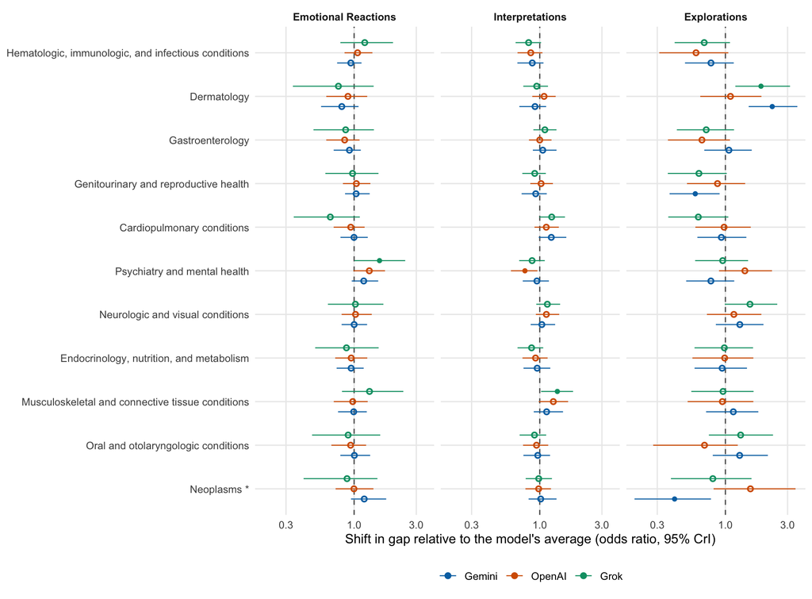

Figure 4.2: Topic shift of the real-vs-AI gap by AI model (odds ratio, log scale). Above 1: gap smaller than that model’s average in that topic; below 1: larger. Filled: credible. Starred topic: exploratory.

Table 4.5: Model-specific topic shifts that are credible.

| Empathy type | Model | Topic | Gap in topic, OR (95% CrI) | Shift, OR (95% CrI) | pd |
| --- | --- | --- | --- | --- | --- |
| Emotional Reactions | Grok | Psychiatry and mental health | 0.040 (0.028-0.055) | 1.57 (1.00-2.47) | 0.980 |
| Interpretations | Grok | Musculoskeletal and connective tissue conditions | 2.67 (2.00-3.50) | 1.37 (1.02-1.80) | 0.993 |
| Interpretations | OpenAI | Psychiatry and mental health | 0.57 (0.45-0.71) | 0.77 (0.60-0.96) | 0.995 |
| Explorations | Gemini | Dermatology | 0.40 (0.30-0.55) | 2.29 (1.51-3.57) | 0.999 |
| Explorations | Gemini | Genitourinary and reproductive health | 0.10 (0.076-0.13) | 0.59 (0.37-0.90) | 0.992 |
| Explorations | Gemini | Neoplasms * | 0.070 (0.037-0.13) | 0.41 (0.20-0.77) | 0.999 |
| Explorations | Grok | Dermatology | 0.062 (0.042-0.094) | 1.88 (1.19-3.13) | 0.997 |

Finally, do two models differ in how a topic affects them? We compared the shifts of each pair of models in each topic (99 comparisons). 2 are credible:

- **Explorations, gemini vs openai, Dermatology:** shift ratio 2.07 (1.06-4.00) (pd 0.990).
- **Explorations, gemini vs openai, Neoplasms (exploratory topic):** shift ratio 0.26 (0.096-0.62) (pd 0.999).

A shift ratio above 1 means the first model gains more than the second in that topic, relative to each model’s own average. Such differences between models are rare, so the topic effects are largely common to the models.

## 4.4 Cancer-related threads

- **Emotional Reactions:** gap 0.097 in other threads, 0.12 (0.088-0.16) in cancer-related threads. No credible difference (shift 1.20 (0.88-1.60), pd 0.886).
- **Interpretations:** gap 0.80 in other threads, 1.19 (0.88-1.67) in cancer-related threads. The gap is credibly smaller in cancer-related threads (shift 1.50 (1.08-2.09), pd 0.993), meaning the AI is relatively better there.
- **Explorations:** gap 0.057 in other threads, 0.039 (0.028-0.053) in cancer-related threads. The gap is credibly larger in cancer-related threads (shift 0.68 (0.49-0.94), pd 0.990), meaning the AI is relatively worse there.

The cancer flag is separate from the “Neoplasms” topic, which is smaller and only includes posts where a clinician or test has raised the concern. A borderline interval (one end near 1) is weak evidence.

## 4.5 Severity

If the real-vs-AI gap depends on how severe the problem is, a severity effect on its own is not enough: it must differ between real and AI replies. We tested this with an interaction between severity and being AI-written, separately for each model. Each number in Table 4.6 is how much the gap changes (multiplies) per additional severity level (the scale runs 1-4). A value above 1 means AI replies catch up with real ones as severity rises; below 1 means they fall further behind.

Table 4.6: Change in the real-vs-AI gap per severity level, factor (95% CrI). * = credible.

|  | Emotional Reactions | Interpretations | Explorations |
| --- | --- | --- | --- |
| Gemini | 1.19 (1.07-1.33) * | 1.50 (1.30-1.70) * | 0.94 (0.84-1.04) |
| OpenAI | 1.35 (1.19-1.54) * | 1.21 (1.08-1.36) * | 1.03 (0.85-1.25) |
| Grok | 0.86 (0.70-1.05) | 1.63 (1.45-1.83) * | 0.94 (0.80-1.11) |
| All AI (mean of the three) | 1.11 (0.99-1.25) | 1.44 (1.29-1.60) * | 0.97 (0.86-1.08) |

For interpretations the gap shrinks with severity for all three models. For emotional reactions this holds for Gemini and OpenAI but not Grok, and the average over the three is borderline. For explorations severity does not change the gap. Threads with no usable severity rating (484 threads) differ strongly in their overall gap, but this probably reflects what kind of post cannot be rated, so we do not interpret it.

## 4.6 Prompting strategies

Each AI model wrote its replies under three prompting strategies, DG, SAG and SAGII. Sections above pool them. Here we ask three questions: do the strategies differ in how far they fall short of real replies, does the strategy change how severity matters, and does it change how topic matters? We report strategy differences *within* each model, because a strategy can work differently in different models. All gaps in this section adjust for reply length unless stated otherwise (see next subsection for why).

### 4.6.1 Reply length and the interpretation gap

How long a reply is matters a lot for what the classifiers detect. Each doubling of length multiplies the odds of showing interpretation by about 2.50, emotional reaction by 1.56, and exploration by 0.84 (shorter replies are more often flagged as exploring). The AI models differ in length: the median real reply has 34 words (mean 54, a long tail), against 35 for Gemini, 80 for OpenAI and 31 for Grok.

Table 4.7 puts three comparisons side by side. *Raw* compares the shares in the first two columns directly. *Within thread, no length adjustment* compares real and AI replies in the same thread, as everywhere in this report. *Within thread, length adjusted* additionally compares replies of the same length.

Table 4.7: Real-vs-AI gap for each AI model: raw shares, within-thread gap, and within-thread gap adjusted for reply length (odds ratio, 95% CrI).

| Empathy type | AI model | Real replies | AI replies | Raw odds ratio | Within thread, no length adjustment | Within thread, length adjusted |
| --- | --- | --- | --- | --- | --- | --- |
| Emotional Reactions | Gemini | 14.7% | 6.7% | 0.42 | 0.30 (0.27-0.33) | 0.33 (0.30-0.37) |
| Emotional Reactions | OpenAI | 14.7% | 3.1% | 0.18 | 0.11 (0.10-0.13) | 0.076 (0.067-0.087) |
| Emotional Reactions | Grok | 14.7% | 0.8% | 0.049 | 0.022 (0.018-0.027) | 0.027 (0.022-0.032) |
| Interpretations | Gemini | 10.7% | 3.6% | 0.31 | 0.27 (0.24-0.30) | 0.44 (0.39-0.51) |
| Interpretations | OpenAI | 10.7% | 12.5% | 1.18 | 1.33 (1.21-1.45) | 0.74 (0.67-0.82) |
| Interpretations | Grok | 10.7% | 11.2% | 1.05 | 1.08 (0.98-1.18) | 1.97 (1.76-2.22) |
| Explorations | Gemini | 18.9% | 5.2% | 0.24 | 0.17 (0.15-0.19) | 0.17 (0.16-0.19) |
| Explorations | OpenAI | 18.9% | 0.9% | 0.040 | 0.019 (0.016-0.022) | 0.024 (0.020-0.029) |
| Explorations | Grok | 18.9% | 1.8% | 0.080 | 0.031 (0.027-0.036) | 0.031 (0.027-0.036) |

For interpretations the adjustment changes the picture. OpenAI’s replies are long, and long replies are classified as interpretation more often, so without the adjustment OpenAI appears to match or exceed real clinicians (raw 12.5% vs. 10.7% for real replies; within-thread gap 1.33 (1.21-1.45)). At equal length it falls behind (0.74 (0.67-0.82)). For Gemini and Grok, whose replies are about as long as the *typical* real reply but shorter than the real average, the adjustment moves the other way: Gemini from 0.27 (0.24-0.30) to 0.44 (0.39-0.51), and Grok from 1.08 (0.98-1.18) to 1.97 (1.76-2.22). For emotional reactions the adjustment matters moderately and for explorations hardly at all.

Which version to quote depends on the question. The unadjusted gap describes the replies as they are; the adjusted gap asks whether an AI reply is as empathic *as a real reply of the same length*. Since length is partly a result of the prompting strategy, the adjusted gap is not simply “more correct”. Everything else in this section uses the adjusted version; the unadjusted one is in the saved results (`v3_group_effects.csv`).

### 4.6.2 Gap by model and strategy

Table 4.8 gives the gap for each of the nine model-by-strategy groups, and for each model averaged over its three strategies.

Table 4.8: Real-vs-AI gap (length adjusted) for each model-by-strategy group, odds ratio (95% CrI).

| AI model | Strategy | Emotional Reactions | Interpretations | Explorations |
| --- | --- | --- | --- | --- |
| Gemini | DG | 0.30 (0.26-0.34) | 0.46 (0.39-0.54) | 0.17 (0.15-0.19) |
| Gemini | SAG | 0.34 (0.29-0.38) | 0.38 (0.32-0.46) | 0.18 (0.16-0.20) |
| Gemini | SAGII | 0.36 (0.31-0.41) | 0.50 (0.42-0.58) | 0.17 (0.15-0.19) |
| Gemini | Mean of three strategies | 0.33 (0.30-0.37) | 0.44 (0.39-0.51) | 0.17 (0.16-0.19) |
| OpenAI | DG | 0.054 (0.045-0.065) | 0.70 (0.62-0.79) | 0.034 (0.027-0.043) |
| OpenAI | SAG | 0.087 (0.074-0.10) | 0.79 (0.70-0.89) | 0.017 (0.012-0.023) |
| OpenAI | SAGII | 0.094 (0.080-0.11) | 0.73 (0.64-0.81) | 0.024 (0.018-0.032) |
| OpenAI | Mean of three strategies | 0.076 (0.067-0.087) | 0.74 (0.67-0.82) | 0.024 (0.020-0.029) |
| Grok | DG | 0.023 (0.017-0.033) | 1.91 (1.67-2.18) | 0.025 (0.020-0.032) |
| Grok | SAG | 0.039 (0.030-0.050) | 1.93 (1.69-2.19) | 0.034 (0.028-0.043) |
| Grok | SAGII | 0.021 (0.015-0.029) | 2.09 (1.83-2.39) | 0.035 (0.027-0.043) |
| Grok | Mean of three strategies | 0.027 (0.022-0.032) | 1.97 (1.76-2.22) | 0.031 (0.027-0.036) |

Differences between models are far larger than differences between strategies. Averaged over strategies, the largest gap between two models is a factor of 12.35 for emotional reactions, 4.43 for interpretations and 7.18 for explorations; between strategies, averaged over models, it is only 1.44, 1.09 and 1.13.

### 4.6.3 Do strategies differ within a model?

Table 4.9 compares strategies directly. Each entry is the ratio of the two strategies’ gaps within the same model: a value below 1 for “DG vs SAG” means DG falls further behind real replies than SAG does; above 1 means DG is closer to real. The last block averages over the three models.

Table 4.9: Differences between prompting strategies in the real-vs-AI gap (length adjusted): ratio of gaps, odds ratio (95% CrI). * = credible.

| AI model | Comparison | Emotional Reactions | Interpretations | Explorations |
| --- | --- | --- | --- | --- |
| Gemini | DG vs SAG | 0.89 (0.77-1.03) | 1.20 (1.00-1.47) | 0.94 (0.82-1.10) |
| Gemini | DG vs SAGII | 0.84 (0.72-0.96) * | 0.93 (0.77-1.09) | 1.00 (0.86-1.17) |
| Gemini | SAG vs SAGII | 0.94 (0.82-1.09) | 0.77 (0.65-0.94) * | 1.07 (0.92-1.24) |
| OpenAI | DG vs SAG | 0.63 (0.51-0.77) * | 0.89 (0.80-0.98) * | 2.00 (1.41-2.96) * |
| OpenAI | DG vs SAGII | 0.58 (0.46-0.70) * | 0.97 (0.87-1.07) | 1.41 (1.01-1.99) * |
| OpenAI | SAG vs SAGII | 0.92 (0.77-1.10) | 1.09 (0.99-1.20) | 0.70 (0.47-1.03) |
| Grok | DG vs SAG | 0.60 (0.41-0.89) * | 0.99 (0.88-1.10) | 0.75 (0.56-1.01) |
| Grok | DG vs SAGII | 1.09 (0.70-1.68) | 0.91 (0.82-1.02) | 0.73 (0.54-0.99) * |
| Grok | SAG vs SAGII | 1.84 (1.27-2.73) * | 0.92 (0.83-1.03) | 0.97 (0.74-1.30) |
| All models (mean) | DG vs SAG | 0.69 (0.59-0.80) * | 1.02 (0.94-1.11) | 1.12 (0.96-1.34) |
| All models (mean) | DG vs SAGII | 0.81 (0.69-0.96) * | 0.94 (0.87-1.01) | 1.01 (0.86-1.18) |
| All models (mean) | SAG vs SAGII | 1.17 (1.01-1.35) * | 0.92 (0.85-1.00) * | 0.90 (0.76-1.06) |

10 of the 27 within-model comparisons and 4 of the 9 pooled comparisons are credible. Three things stand out:

- **Emotional reactions:** DG is the weakest strategy on average (DG vs SAG 0.69 (0.59-0.80), DG vs SAGII 0.81 (0.69-0.96)). This is driven by OpenAI (DG vs SAG 0.63 (0.51-0.77)) and by Grok, where SAG comes closest to real replies (DG vs SAG 0.60 (0.41-0.89); SAG vs SAGII 1.84 (1.27-2.73)).
- **Interpretations:** the pooled comparisons are close to 1; only SAG vs SAGII (0.92 (0.85-1.00)) is credible, and its interval ends at 1. Within models, the credible differences are small: Gemini SAG vs SAGII 0.77 (0.65-0.94) and OpenAI DG vs SAG 0.89 (0.80-0.98).
- **Explorations:** no pooled difference. Within OpenAI the DG gap is about twice that of SAG (DG vs SAG 2.00 (1.41-2.96)), i.e. DG is *closer* to real replies, but the explorations gaps of OpenAI and Grok are very large (odds roughly 30 to 40 times lower than real), so these ratios describe small differences between small rates.

Because the sign and size of strategy differences change from model to model, “which strategy is best” has no model-independent answer. The evidence for the borderline comparisons (pd just above or below 0.975) is not strong enough to single any of them out (see Section 4.8).

### 4.6.4 Does severity matter differently for each strategy?

Section 4.5 tested whether the gap changes with severity, per model. Table 4.10 does so for each of the nine groups (extra change in the gap per severity level; above 1 = the AI catches up as severity rises).

Table 4.10: Change in the real-vs-AI gap per severity level, by model and strategy, factor (95% CrI). * = credible.

| AI model | Strategy | Emotional Reactions | Interpretations | Explorations |
| --- | --- | --- | --- | --- |
| Gemini | DG | 1.08 (0.94-1.27) | 1.41 (1.18-1.68) * | 0.97 (0.84-1.13) |
| Gemini | SAG | 1.24 (1.07-1.42) * | 1.59 (1.31-1.94) * | 0.93 (0.80-1.08) |
| Gemini | SAGII | 1.25 (1.08-1.43) * | 1.51 (1.27-1.79) * | 0.92 (0.79-1.06) |
| Gemini | Mean of three strategies | 1.19 (1.07-1.33) * | 1.50 (1.30-1.71) * | 0.94 (0.84-1.04) |
| OpenAI | DG | 1.49 (1.21-1.87) * | 1.20 (1.04-1.38) * | 1.15 (0.89-1.52) |
| OpenAI | SAG | 1.50 (1.26-1.77) * | 1.21 (1.07-1.39) * | 1.05 (0.72-1.55) |
| OpenAI | SAGII | 1.18 (1.00-1.38) * | 1.22 (1.07-1.39) * | 0.85 (0.62-1.19) |
| OpenAI | Mean of three strategies | 1.38 (1.21-1.57) * | 1.21 (1.08-1.36) * | 1.01 (0.83-1.24) |
| Grok | DG | 0.73 (0.49-1.03) | 1.68 (1.46-1.93) * | 0.94 (0.71-1.24) |
| Grok | SAG | 0.90 (0.67-1.19) | 1.59 (1.40-1.83) * | 0.99 (0.77-1.28) |
| Grok | SAGII | 0.93 (0.64-1.33) | 1.62 (1.41-1.86) * | 0.89 (0.69-1.13) |
| Grok | Mean of three strategies | 0.85 (0.69-1.05) | 1.63 (1.45-1.83) * | 0.94 (0.79-1.10) |

For interpretations the severity effect is credible in 9 of 9 groups, whichever strategy was used. For emotional reactions it is credible in 5 of 9 groups and for explorations in 0. Strategies barely differ in how severity matters: of the 36 strategy comparisons of severity slopes (all three kinds of empathy, within models and pooled), 1 is credible. So the severity result of Section 4.5 holds for each prompting strategy, not only on average.

### 4.6.5 Does topic matter differently for each model or strategy?

Estimating a separate topic effect for each of the nine groups (plus their correlations) is beyond what 11 topics can support (see Outlook). Instead we let each topic’s shift have extra variation by AI model, by strategy and by model-strategy group, each with one shared spread (standard deviation). A spread near zero means topic does not matter differently for different models or strategies.

Table 4.11: Spread (SD, log-odds scale) of topic shifts of the real-vs-AI gap and its variation by model and strategy (95% CrI).

| Source of variation in the topic shift | Emotional Reactions | Interpretations | Explorations |
| --- | --- | --- | --- |
| Topic shift shared by all groups (for reference) | 0.21 (0.05-0.40) | 0.25 (0.12-0.43) | 0.29 (0.00-0.59) |
| Extra variation by AI model | 0.09 (0.00-0.20) | 0.05 (0.00-0.11) | 0.36 (0.20-0.55) |
| Extra variation by prompting strategy | 0.04 (0.00-0.11) | 0.02 (0.00-0.06) | 0.03 (0.00-0.09) |
| Extra variation by model-strategy group | 0.03 (0.00-0.10) | 0.02 (0.00-0.05) | 0.03 (0.00-0.10) |

Topic effects vary very little by prompting strategy or by model-strategy combination (estimated spreads of 0.04 or less). By AI model the variation is small for emotional reactions and interpretations but substantial for explorations (0.36, interval clearly above zero), in line with the two credible model differences for explorations found in Section 4.3. Strategy therefore does not change *how topic matters*, beyond what the model already does.

1 individual deviation is credible:

- **Explorations, Neoplasms, Gemini (exploratory topic):** shift 0.51 (0.27-0.89) (pd 0.995).

### 4.6.6 Interpretations without the topic intercept

The pooled topic model for interpretations in v2 had a few divergent transitions, probably because the *baseline* differences between topics (the random topic intercept) are almost zero for interpretations. We refitted it without that intercept, with a stricter sampler setting, as a check.

Table 4.12: Interpretations: topic shifts of the gap, with and without the random topic intercept. * = credible; shown if credible in either.

| Topic | Pooled topic model, shift (v2) | Without topic intercept, shift |
| --- | --- | --- |
| Hematologic, immunologic, and infectious conditions | 0.77 (0.60-0.96) (pd 0.987) * | 0.75 (0.62-0.90) (pd 0.998) * |
| Cardiopulmonary conditions | 1.30 (1.04-1.65) (pd 0.991) * | 1.30 (1.07-1.57) (pd 0.993) * |
| Psychiatry and mental health | 0.77 (0.60-0.95) (pd 0.992) * | 0.77 (0.62-0.93) (pd 0.993) * |
| Musculoskeletal and connective tissue conditions | 1.45 (1.12-1.89) (pd 0.998) * | 1.46 (1.19-1.83) (pd 0.999) * |

The same 4 topics are credible in both versions and the shifts are almost identical (largest difference 3% on the odds-ratio scale). The divergences therefore did not distort the topic findings for interpretations.

## 4.7 Other covariates

Table 4.13 shows how the other thread characteristics relate to whether replies (real and AI alike, except where noted) show empathy. These effects apply to the baseline rate, not the gap. Age is per decade; severity per level; each is relative to a reference level (first-person posts, female patients, rated severity, undeclared specialty).

Table 4.13: Association of thread characteristics with showing empathy, odds ratio (95% CrI). * = credible.

|  | Emotional Reactions | Interpretations | Explorations |
| --- | --- | --- | --- |
| Post is about someone else | 1.15 (0.95-1.39) | 2.37 (2.09-2.70) * | 0.97 (0.80-1.19) |
| Post subject unclear | 0.82 (0.68-0.97) * | 1.22 (1.09-1.36) * | 1.06 (0.90-1.25) |
| Age (per decade) | 1.04 (0.99-1.09) | 1.09 (1.06-1.13) * | 0.97 (0.92-1.02) |
| Age not stated | 0.88 (0.72-1.07) | 1.07 (0.93-1.23) | 0.96 (0.78-1.18) |
| Male (vs. female) | 0.99 (0.87-1.12) | 0.96 (0.87-1.06) | 0.95 (0.83-1.09) |
| Sex not stated | 1.17 (0.98-1.40) | 1.06 (0.93-1.20) | 0.99 (0.82-1.19) |
| Severity (per level) | 1.15 (1.07-1.23) * | 1.16 (1.10-1.22) * | 1.27 (1.18-1.37) * |
| Severity not rated | 2.53 (2.07-3.08) * | 1.11 (0.94-1.30) | 0.61 (0.47-0.79) * |
| Real reply: first responder’s specialty matches topic | 0.58 (0.38-0.84) * | 0.81 (0.54-1.16) | 0.45 (0.33-0.62) * |
| Real reply: first responder’s specialty differs from topic | 0.71 (0.50-0.98) * | 1.32 (0.94-1.87) | 0.55 (0.40-0.76) * |

Briefly: more severe problems draw more empathy of all kinds from both real and AI replies; posts about someone else draw more interpretation (OR about 2.4); the demographic variables have small effects (a few reach credibility, such as age for interpretations). Real replies in threads where the first responder declared a body-system specialty show less emotional reaction and exploration than threads without a declared specialty, whether or not the specialty matches the topic. This probably reflects how specialists write, or who chooses to declare a specialty, rather than the match itself.

## 4.8 Robustness: thinning instead of weighting

The main models use all AI replies and give each a weight so that a thread’s AI replies carry no more total weight than its real replies. A different way to treat the surplus is to randomly discard AI replies: in every thread, model and strategy, we kept as many AI replies as the thread has real replies (at random; cells with fewer replies are kept whole) and gave every reply weight 1. This leaves 77,603 AI replies instead of 128,653. We then refitted all strategy models (length-adjusted and unadjusted gaps, severity by group, topic by model and strategy) on the thinned data and compared them with the weighted fits.

Table 4.14: Weighted vs. thinned fits: how many estimates are credible in each, and how much the odds ratios move.

| Quantity | Estimates | Credible, weighted | Credible, thinned | Credibility differs | Largest change in odds ratio |
| --- | --- | --- | --- | --- | --- |
| gap, length adjusted, per model-by-strategy group | 27 | 27 | 27 | 0 | 14% |
| gap, length adjusted, per AI model | 9 | 9 | 9 | 0 | 9% |
| gap, length adjusted, per strategy | 9 | 8 | 8 | 0 | 6% |
| gap, length adjusted, strategy contrasts within a model | 27 | 10 | 14 | 6 | 9% |
| gap, length adjusted, strategy contrasts, pooled over models | 9 | 4 | 5 | 1 | 3% |
| gap, no length adjustment, per model-by-strategy group | 27 | 24 | 24 | 0 | 12% |
| gap, no length adjustment, per AI model | 9 | 8 | 8 | 0 | 9% |
| gap, no length adjustment, per strategy | 9 | 9 | 9 | 0 | 6% |
| gap, no length adjustment, strategy contrasts within a model | 27 | 14 | 15 | 1 | 7% |
| gap, no length adjustment, strategy contrasts, pooled over models | 9 | 4 | 5 | 1 | 2% |
| severity slope, per model-by-strategy group | 27 | 14 | 14 | 0 | 10% |
| severity slope, per AI model | 9 | 5 | 5 | 0 | 4% |
| severity slope, per strategy | 9 | 4 | 4 | 0 | 4% |
| severity slope, strategy contrasts within a model | 27 | 1 | 1 | 0 | 13% |
| severity slope, strategy contrasts, pooled over models | 9 | 0 | 1 | 1 | 6% |

The estimates are almost the same: the median change in an odds ratio is 2%, the largest 14%, and the intervals have the same width (median ratio of interval widths 1.01). The effect of length, the severity effects and the model gaps all reproduce, and so does the topic-by-model spread for explorations (0.36 weighted). 10 of the 243 estimates differ in whether they are credible. All of them are comparisons between prompting strategies, with pd values between 0.92 and 0.99 in both fits:

Table 4.15: Estimates whose credibility status differs between the weighted and the thinned fits.

| Empathy type | Quantity | Which | Weighted | Thinned |
| --- | --- | --- | --- | --- |
| Emotional Reactions | gap, no length adjustment, strategy contrasts, pooled over models | All models SAG vs SAGII | 1.16 (1.00-1.36) (pd 0.974) | 1.19 (1.02-1.38) (pd 0.985) |
| Interpretations | gap, length adjusted, strategy contrasts within a model | Gemini DG vs SAG | 1.20 (1.00-1.47) (pd 0.968) | 1.21 (1.01-1.46) (pd 0.978) |
| Interpretations | gap, length adjusted, strategy contrasts within a model | Grok DG vs SAGII | 0.91 (0.82-1.02) (pd 0.940) | 0.88 (0.79-0.98) (pd 0.989) |
| Interpretations | gap, length adjusted, strategy contrasts within a model | Grok SAG vs SAGII | 0.92 (0.83-1.03) (pd 0.922) | 0.90 (0.80-0.99) (pd 0.981) |
| Interpretations | gap, length adjusted, strategy contrasts, pooled over models | All models DG vs SAGII | 0.94 (0.87-1.01) (pd 0.960) | 0.92 (0.86-1.00) (pd 0.978) |
| Explorations | gap, no length adjustment, strategy contrasts within a model | OpenAI SAG vs SAGII | 0.70 (0.45-1.00) (pd 0.965) | 0.66 (0.44-0.97) (pd 0.980) |
| Explorations | gap, length adjusted, strategy contrasts within a model | OpenAI DG vs SAGII | 1.41 (1.01-1.99) (pd 0.978) | 1.33 (0.95-1.86) (pd 0.953) |
| Explorations | gap, length adjusted, strategy contrasts within a model | OpenAI SAG vs SAGII | 0.70 (0.47-1.03) (pd 0.963) | 0.65 (0.44-0.95) (pd 0.985) |
| Explorations | gap, length adjusted, strategy contrasts within a model | Grok DG vs SAG | 0.75 (0.56-1.01) (pd 0.969) | 0.73 (0.54-1.00) (pd 0.978) |
| Explorations | severity slope, strategy contrasts, pooled over models | All models DG vs SAGII | 1.15 (0.95-1.37) (pd 0.922) | 1.21 (1.00-1.47) (pd 0.977) |

Nine of the ten are credible in the thinned fit but not in the weighted one; one (OpenAI, DG vs SAGII for explorations) is the reverse. We therefore treat strategy comparisons near the threshold as inconclusive rather than as findings.

The topic findings are also stable. In the topic-by-model-and-strategy model, the pooled topic shifts change by at most 5%. 6 shifts are credible with weighting and 4 after thinning; the ones that lose credibility are Emotional Reactions, Dermatology (shift 0.71 to 0.75, pd 0.982 to 0.965); Interpretations, Hematologic, immunologic, and infectious conditions (shift 0.78 to 0.80, pd 0.984 to 0.970). Weighting and thinning therefore give the same picture, which supports the choice not to discard any replies. This is a single random thinning; repeating it would show how much results vary between thinnings.

# 5 Methods

## 5.1 Data and outcomes

All 137,278 rated replies from 6,600 threads are used, with no outlier exclusion and no subsampling (a subsampling sensitivity check is described below). Synthetic replies come from Gemini, OpenAI and Grok, each under three prompting strategies (DG, SAG, SAGII), giving nine synthetic groups plus the real group. Empathy labels (0/1/2) for ER, IP and EX come from three fine-tuned RoBERTa bi-encoder classifiers following EPITOME. The binary outcome is `label >= 1`. For IP and EX label 1 never occurs in these data, so this equals `label == 2`.

## 5.2 Topics and covariates

Topic labels come from the collaborators’ pipeline (`classify_topics.py`): gemini-2.5-pro at temperature 0, one of 17 disciplines per opening post, joined on `submission_id`. Production-model agreement with a 200-post reference sample was 0.770 (agreement between the two LLM annotators who built it: 0.795, $\kappa$ = 0.779). Four merges: Pulmonology + Cardiovascular, Dentistry + Otolaryngology, Ophthalmology + Neurology, Hematology and immunology + Infectious diseases. “Nonmedical” and “Medical; other” are excluded from the topic models. Topics under 5% of all threads are flagged exploratory but kept.

Covariates (all thread-level): `subject` (first person / third party / unknown); `age10` (age in decades, centred at the median; missing set to 0 with indicator `age_na`); `sex3` (female / male / unknown); `sev_c` (severity 1-4, centred at the mean; “not applicable” and blank set to 0 with indicator `sev_na`); `real_match` and `real_mismatch` (1 for real replies when the first responder declared a body-system specialty that matches / does not match the merged topic, else 0; reference: no declared body-system specialty; 0 for all synthetic replies). Not used: weight, height, BMI, race, smoking, drinking and time to first response, following the collaborator’s documentation (heavy or topic-dependent missingness).

## 5.3 Response weights

With $n_c$ synthetic replies in a (thread, model, method) cell and $r$ real replies in the thread, real replies have weight 1 and synthetic ones $w = \min(1, r / n_c)$. Weights are computed on all threads before topic filtering. In the subsampling check (Section 4.8), each such cell with $n_c>r$ synthetic replies is instead thinned to $r$ randomly chosen replies (seed 1, one draw), all weights are 1, and everything else is unchanged. They enter the log-likelihood as multipliers (`brms` `weights()`), so estimates target the average over random per-thread subsampling but posterior intervals are approximate.

## 5.4 Models

Fitted separately for ER, IP and EX; Bernoulli likelihood, logit link. For reply $i$: $s_i$ indicates a synthetic reply, $s_{iL}$ a reply from model $L$ (Gemini, OpenAI, Grok), $\beta_{g(i)}$ the coefficient for its group, $\mathbf{x}_i$ the covariates above, $\ell_i$ log reply length in words, $t(i)$ its thread’s topic and $p(i)$ the thread.

**C2 (pooled topic moderation).**
$$\operatorname{logit} P(y_i=1)=\alpha+\beta_{g(i)}+\mathbf{x}_i^\top\boldsymbol\delta+\gamma\ell_i+u_{t(i)}+v_{t(i)}s_i+a_{p(i)}$$
with $(u_t,v_t)\sim\mathcal N(0,\Sigma)$, $a_p\sim\mathcal N(0,\sigma_p^2)$. A topic’s gap is the mean of the nine synthetic $\beta_g$ plus $v_t$ (the shift), exponentiated.

**E (topic moderation per model).** Replace $v_{t}s_i$ by $\sum_L v_{tL}s_{iL}$, with $(u_t,v_{t,\mathrm{gem}},v_{t,\mathrm{opn}},v_{t,\mathrm{grk}})\sim\mathcal N(0,\Sigma)$ and an LKJ(2) prior on the correlations. A model’s gap in a topic is the mean of its three $\beta_g$ plus $v_{tL}$. Differences between models are computed from the draws (ratio of gap ORs, ratio of shift ORs).

**D2 (cancer).** No topic effects; $\ldots+\eta c_{p(i)}+\theta s_ic_{p(i)}+\ldots$ with cancer flag $c$; $\theta$ is the moderation.

**F (severity).** Model C2 plus $\sum_L\lambda_L s_{iL}\,\mathrm{sev}_i+\kappa s_i\,\mathrm{sevNA}_i$. Since severity is also a covariate, $\lambda_L$ is the *extra* change in model $L$’s gap per severity level, over and above any effect of severity on real replies; the pooled value is the mean of the three. Topic effects stay in the model so severity does not stand in for topic.

**L0 and L1 (strategy main effects).** Let $\beta_g$ be the coefficient of one of the nine synthetic groups $g$ (model-by-strategy), real replies being the reference:
$$\operatorname{logit} P(y_i=1)=\alpha+\beta_{g(i)}+\mathbf{x}_i^\top\boldsymbol\delta\,[+\gamma\ell_i]+a_{p(i)}.$$
L0 omits the length term, L1 includes it. A group’s gap is $e^{\beta_g}$; a model’s gap is the exponentiated mean of its three $\beta_g$; a strategy’s gap the mean over the three models; strategy contrasts are differences of these quantities, computed from the draws.

**H (severity per group).** Model C2 with the length term, plus $\sum_g\lambda_g\,\mathbb 1[g(i)=g]\,\mathrm{sev}_i+\kappa s_i\,\mathrm{sevNA}_i$, nine severity slopes instead of three. Slopes are summarised like the gaps above.

**I (topic by model and strategy).** Model C2 with the length term, plus extra topic shifts $w_{t,L(i)}s_i+z_{t,m(i)}s_i+q_{t,g(i)}s_i$ by topic and AI model, topic and strategy, and topic and group, with $w_{tL}\sim\mathcal N(0,\sigma_{TL}^2)$, $z_{tm}\sim\mathcal N(0,\sigma_{TM}^2)$, $q_{tg}\sim\mathcal N(0,\sigma_{TG}^2)$ (one shared SD each; Normal(0, 1) prior truncated at 0). Real replies have a dummy level with no data. The SDs say how much topic moderation varies by model, strategy and group; individual deviations are reported but not interpreted as findings unless credible.

**Sensitivity for IP.** C2 with length adjustment, without the random topic intercept $u_t$, `adapt_delta` = 0.99.

## 5.5 Priors, sampling, convergence

Fixed effects: Normal(0, 2.5). Intercept and thread SD: Student-$t$(3, 0, 2.5). Topic SDs: Normal(0, 1), truncated at 0. `brms` with `cmdstanr`; 4 chains of 2,000 iterations (1,000 warmup), 4 threads per chain, `adapt_delta` = 0.95, seed 20260101. A fit is accepted when max $\hat R<1.01$, minimum effective-sample-size ratio $>0.1$ and there are no divergent transitions. Seven fits that fell marginally short (cancer models for all three kinds of empathy, severity models for ER and EX, pooled topic models for IP and EX) were refitted with 4,000 iterations (1,000 warmup); the credible topic effects were unchanged. The refit of the IP pooled topic model improved $\hat R$ but still has divergent transitions (reported under Model checks), as in our earlier topic analysis; the topic-level intercept SD for interpretations is close to zero, which makes the sampler’s job harder. The strategy fits (L0, L1, H, I and the IP sensitivity fit) and the subsampling-check fits use the same settings; four strategy fits that were marginal at 2,000 iterations (IP and EX severity-by-group, EX topic-by-group, IP sensitivity) were refitted with 4,000. Multithreaded summation makes draws non-reproducible from the seed alone, so the saved fits (`models_bayesian/`) and the run metadata are the reproducible artefacts.

## 5.6 Reporting

Posterior median odds ratio, 95% highest-density interval and $pd=\max\{P(\theta>0),P(\theta<0)\}$ on the log-odds scale. Credible: pd > 0.975 and the interval excludes 1. No frequentist multiplicity correction; topic effects are partially pooled instead. Code: `3i_topic_llm_moderation_v2.R` (topic, model, severity, cancer), `3j_strategy_models.R` (prompting strategies, length adjustment, IP sensitivity and, with `SUBS_SEED`, the subsampling check) and `3k_subsampling_*.R` (comparison of weighted and thinned fits).

## 5.7 Limitations

- Misclassified topics attenuate moderation estimates; no correction applied.
- Topic effects by strategy and by model-strategy group are summarised by variance components only; individual deviations are noisy and mostly not credible.
- Length-adjusted gaps compare replies of the same length; since length is partly caused by the strategy, they complement rather than replace the unadjusted gaps.
- The subsampling check is one random draw; six of its twelve fits narrowly missed the convergence rule (Model checks).
- With 11 topics, correlations between models’ topic shifts are poorly determined, and topic-specific cells for single models are noisy.
- The cancer flag is a distinct construct from the Neoplasms topic.
- Specialty match and severity are observational; severity not-rated threads have a different gap, which we do not interpret.
- Weighted intervals are approximate.

# 6 Outlook: what we did not do

- **The full topic-by-strategy-by-model model.** A separate topic shift for each of the nine groups with their correlations is not impossible to run, but the data cannot support it: it needs 55 covariance parameters from 11 topics, cells are sparse (for example about 2% of Grok’s replies show exploration), and it would produce around 300 topic-by-group estimates per kind of empathy. The variance components in Section 4.6 are the estimable version of the question and say that, beyond the model, strategy hardly changes how topic matters.
- **Topic by severity.** Whether severity matters differently in different topics was not tested.
- **More than one thinning.** The subsampling check used one random draw.
- **Cleaner topic labels.** About one topic label in four may be wrong. A human-coded validation set would quantify how much this blurs the topic results.